# Introduzione Data Wrangling di Immagini Geospaziali 🛰️ 🌍

[figure not shown]

In questo tutorial vedremo come poter accedere ai dati del satellite [Sentinel-2](https://sentinel.esa.int/web/sentinel/missions/sentinel-2). Vedremo alcune librerie comuni utilizzate nel Geospatial Data Science ed il loro utilizzo per accere ai dati utili al progetto Copernicus.

In particolare vedremo:

1. Come generare un footprint (ossia come definire l'area di studio)
2. Come interrogare il database di delle immagini delle missioni Sentinel (ossia il [Copernicus Open Access Hub](https://scihub.copernicus.eu/))
3. Come scaricare ed estrarre i file interessanti
4. Come leggere, scrivere ed infine manipolare le immagini riprese.

*Tutorial by* **[Francesco Pelosin](https://francesco-p.github.io/)**

# Installazione prerequisiti

```python
!apt install ffmpeg
!pip install geopandas
!pip install folium
!pip install sentinelsat
!pip install rasterio
!pip install opencv-python
!pip install imageio
```

```
Reading package lists... Done
Building dependency tree
Reading state information... Done
ffmpeg is already the newest version (7:3.4.6-0ubuntu0.18.04.1).
The following package was automatically installed and is no longer required:
  libnvidia-common-430
Use 'apt autoremove' to remove it.
0 upgraded, 0 newly installed, 0 to remove and 7 not upgraded.
     |████████████████████████████████| 921kB 4.8MB/s
     |████████████████████████████████| 11.8MB 43.9MB/s
     |████████████████████████████████| 10.1MB 33.0MB/s
     |████████████████████████████████| 18.0MB 246kB/s
```

```python
# Librerie specifiche per lavorare con dati Geospaziali
import geopandas as gpd
import folium
from sentinelsat import SentinelAPI, read_geojson, geojson_to_wkt

# Librerie specifiche per lavorare con dati immagine
import rasterio as rio
import rasterio.mask
from rasterio.plot import show
import matplotlib.pyplot as plt
import imageio
import cv2

# Libreria calcolo vettoriale
import numpy as np

# Librerie di aiuto per l'interfaccia OS
import zipfile
import os
import base64
from IPython.display import HTML
```

```python
# Preparazione delle cartelle necessarie
if not os.path.exists("./data/"):
    os.makedirs("./data/")
if not os.path.exists("./video/"):
    os.makedirs("./video/")
if not os.path.exists("./imgs/"):
    os.makedirs("./imgs/")
if not os.path.exists("./geoj/"):
    os.makedirs("./geoj/")

def rim_info(rim):
    print(f"Number of bands: {rim.count}")
    print(f"Dset bounds: {rim.bounds}")
    print(f"{(rim.bounds.top - rim.bounds.bottom)/ 1000} km² high")
    print(f"{(rim.bounds.right - rim.bounds.left)/ 1000} km² wide")

def playvideo(filename):
    video = open(filename, 'r+b').read()
    encoded = base64.b64encode(video)
    return HTML(data='''<video alt="test" controls><source src="data:video/mp4;base64,{0}" type="video/mp4"/></video>'''.format(encoded.decode('ascii')))


def get_bands_files(R_dir):

    bands_dict = {}

    for x in os.listdir(R_dir):
        if ('_B08_' in x):
            bands_dict['B08'] = R_dir+x
        elif ('_B12_' in x):
            bands_dict['B12'] = R_dir+x
        elif ('_B11_' in x):
            bands_dict['B11'] = R_dir+x
        elif ('_B07_' in x):
            bands_dict['B07'] = R_dir+x
        elif ('_B06_' in x):
            bands_dict['B06'] = R_dir+x
        elif ('_B05_' in x):
            bands_dict['B05'] = R_dir+x
        elif ('_B04_' in x):
            bands_dict['B04'] = R_dir+x
        elif ('_B03_' in x):
            bands_dict['B03'] = R_dir+x
        elif ('_B02_' in x):
            bands_dict['B02'] = R_dir+x
        else:
            pass

    return bands_dict
```

# Selezione dell'area di studio (footprint)

- Identifico l'area di studio attraverso un `.geojson` nello specifico utilizziamo questo servizio online http://geojson.io/
- Cosa sono i file `.geojson`?
- Cos'è il formato wkt?

```python
%%writefile ./geoj/venezia.geojson
{
  "type": "FeatureCollection",
  "features": [
    {
      "type": "Feature",
      "properties": {},
      "geometry": {
        "type": "Polygon",
        "coordinates": [
          [
            [
              12.316017150878906,
              45.46807675634549
            ],
            [
              12.284774780273438,
              45.4324308667588
            ],
            [
              12.288551330566406,
              45.340080499681875
            ],
            [
              12.344512939453125,
              45.33284041773058
            ],
            [
              12.41455078125,
              45.44471679159555
            ],
            [
              12.441329956054688,
              45.47433654565603
            ],
            [
              12.316017150878906,
              45.46807675634549
            ]
          ]
        ]
      }
    }
  ]
}
```

```
Writing ./geoj/venezia.geojson
```

```python
# Selezione del nostro .geojson file
GEOJSON_FILE = './geoj/venezia.geojson'

# Generazione del poligono in formato wkt
footprint = geojson_to_wkt(read_geojson(GEOJSON_FILE))
print(f"Stringa identificativa del poligono disegnato in formato wtk:\n{footprint}")

# Visualizzazione del poligono
bounds = folium.GeoJson(GEOJSON_FILE).get_bounds()
c_lat = (bounds[0][0] + bounds[1][0])/2
c_lon = (bounds[0][1] + bounds[1][1])/2
m = folium.Map([c_lat,c_lon], tiles='Stamen Terrain')
folium.GeoJson(GEOJSON_FILE).add_to(m)

m
```

```
Stringa identificativa del poligono disegnato in formato wtk:
POLYGON((12.3160 45.4681,12.2848 45.4324,12.2886 45.3401,12.3445 45.3328,12.4146 45.4447,12.4413 45.4743,12.3160 45.4681))
```

[interactive chart not shown]

# Sentinelsat API

- Iscriversi al sito ufficiale scihub https://scihub.copernicus.eu/dhus/#/home
- Premier sulle API

## Credenziali

```python
# Credenziali
USER = 'YOURUSR'
PSW = 'YOURPSW'
```

## Inizializzazione API

```python
# Inizializzazione oggetto API
api = SentinelAPI(USER, PSW, 'https://scihub.copernicus.eu/dhus')

# Parametri query
INIT_DATE = '20190101'
END_DATE = '20191115'
PLATFORM_NAME = 'Sentinel-2'
PROCESSING_LEVEL = 'Level-2A'

# Ricerca tramite area di studio
products = api.query(footprint,
                     date = (INIT_DATE, END_DATE),
                     platformname=PLATFORM_NAME,
                     processinglevel = PROCESSING_LEVEL,
                     cloudcoverpercentage = (0,90))
print(f"{len(products)} prodotti trovati.")
```

```
197 prodotti trovati.
```

# Conversione dei risultati in formato Geodataframe

- Cos'è un Geodataframe?

```python
products_gdf = api.to_geodataframe(products)
products_gdf_sorted = products_gdf.sort_values(['cloudcoverpercentage'], ascending=[True])
print(products_gdf_sorted['cloudcoverpercentage'])
products_gdf_sorted
```

```
7d5a2b8d-c54a-41fe-8bbd-4c11ccf85583     0.113177
6db6191b-027d-456d-96fa-9d57178100c3     0.131045
b83bd2bf-ee8b-45ca-a8ec-0c43635be2de     0.142274
9e4073ae-201c-4c0e-9b83-7c48323e63af     0.145452
f8ce8bf4-1d81-4e70-8a4d-b0bcce7430f3     0.145875
                                          ...
39481b9b-983e-4a87-8c4d-e42428fa2828    88.701160
aa6f66b6-5b0b-4ee8-bd2d-f74f5cf81287    89.633872
0eeae2ef-24f1-4c19-8f98-403252775992    89.696455
c3694ba9-2f11-40ea-9537-051bf9bb2552    89.804619
411745d3-fbb7-445d-bdba-91fa75286984    89.872329
Name: cloudcoverpercentage, Length: 197, dtype: float64
```

|  | title | link | link_alternative | link_icon | summary | beginposition | endposition | ingestiondate | orbitnumber | relativeorbitnumber | cloudcoverpercentage | highprobacloudspercentage | mediumprobacloudspercentage | snowicepercentage | vegetationpercentage | waterpercentage | notvegetatedpercentage | unclassifiedpercentage | format | instrumentshortname | instrumentname | s2datatakeid | platformidentifier | orbitdirection | platformserialidentifier | processingbaseline | processinglevel | producttype | platformname | … |
| --- | --- | --- | --- | --- | --- | --- | --- | --- | --- | --- | --- | --- | --- | --- | --- | --- | --- | --- | --- | --- | --- | --- | --- | --- | --- | --- | --- | --- | --- | --- |
| 7d5a2b8d-c54a-41fe-8bbd-4c11ccf85583 | S2B_MSIL2A_20190628T101039_N0212_R022_T33TUL_2... | https://scihub.copernicus.eu/dhus/odata/v1/Pro... | https://scihub.copernicus.eu/dhus/odata/v1/Pro... | https://scihub.copernicus.eu/dhus/odata/v1/Pro... | Date: 2019-06-28T10:10:39.024Z, Instrument: MS... | 2019-06-28 10:10:39.024 | 2019-06-28 10:10:39.024 | 2019-06-29 06:49:52.422 | 12060 | 22 | 0.113177 | 0.050634 | 0.059140 | 0.000026 | 29.085377 | 55.206275 | 15.085511 | 0.273470 | SAFE | MSI | Multi-Spectral Instrument | GS2B_20190628T101039_012060_N02.12 | 2017-013A | DESCENDING | Sentinel-2B | 02.12 | Level-2A | S2MSI2A | Sentinel-2 | … |
| 6db6191b-027d-456d-96fa-9d57178100c3 | S2B_MSIL2A_20191026T101029_N0213_R022_T32TQR_2... | https://scihub.copernicus.eu/dhus/odata/v1/Pro... | https://scihub.copernicus.eu/dhus/odata/v1/Pro... | https://scihub.copernicus.eu/dhus/odata/v1/Pro... | Date: 2019-10-26T10:10:29.024Z, Instrument: MS... | 2019-10-26 10:10:29.024 | 2019-10-26 10:10:29.024 | 2019-10-26 20:10:00.902 | 13776 | 22 | 0.131045 | 0.064635 | 0.064578 | 0.000156 | 35.929367 | 26.902407 | 29.680073 | 3.767464 | SAFE | MSI | Multi-Spectral Instrument | GS2B_20191026T101029_013776_N02.13 | 2017-013A | DESCENDING | Sentinel-2B | 02.13 | Level-2A | S2MSI2A | Sentinel-2 | … |
| b83bd2bf-ee8b-45ca-a8ec-0c43635be2de | S2A_MSIL2A_20190114T101351_N0211_R022_T33TUL_2... | https://scihub.copernicus.eu/dhus/odata/v1/Pro... | https://scihub.copernicus.eu/dhus/odata/v1/Pro... | https://scihub.copernicus.eu/dhus/odata/v1/Pro... | Date: 2019-01-14T10:13:51.024Z, Instrument: MS... | 2019-01-14 10:13:51.024 | 2019-01-14 10:13:51.024 | 2019-01-14 20:09:46.646 | 18609 | 22 | 0.142274 | 0.045427 | 0.090002 | 0.006662 | 10.416094 | 55.362308 | 18.290167 | 9.357703 | SAFE | MSI | Multi-Spectral Instrument | GS2A_20190114T101351_018609_N02.11 | 2015-028A | DESCENDING | Sentinel-2A | 02.11 | Level-2A | S2MSI2A | Sentinel-2 | … |
| 9e4073ae-201c-4c0e-9b83-7c48323e63af | S2A_MSIL2A_20190401T100031_N0211_R122_T33TUL_2... | https://scihub.copernicus.eu/dhus/odata/v1/Pro... | https://scihub.copernicus.eu/dhus/odata/v1/Pro... | https://scihub.copernicus.eu/dhus/odata/v1/Pro... | Date: 2019-04-01T10:00:31.024Z, Instrument: MS... | 2019-04-01 10:00:31.024 | 2019-04-01 10:00:31.024 | 2019-04-01 23:53:15.602 | 19710 | 122 | 0.145452 | 0.062653 | 0.080739 | 0.000040 | 22.991164 | 51.197332 | 24.381883 | 0.784877 | SAFE | MSI | Multi-Spectral Instrument | GS2A_20190401T100031_019710_N02.11 | 2015-028A | DESCENDING | Sentinel-2A | 02.11 | Level-2A | S2MSI2A | Sentinel-2 | … |
| f8ce8bf4-1d81-4e70-8a4d-b0bcce7430f3 | S2A_MSIL2A_20190921T101031_N0213_R022_T33TUL_2... | https://scihub.copernicus.eu/dhus/odata/v1/Pro... | https://scihub.copernicus.eu/dhus/odata/v1/Pro... | https://scihub.copernicus.eu/dhus/odata/v1/Pro... | Date: 2019-09-21T10:10:31.024Z, Instrument: MS... | 2019-09-21 10:10:31.024 | 2019-09-21 10:10:31.024 | 2019-09-21 18:39:25.293 | 22184 | 22 | 0.145875 | 0.075595 | 0.066192 | 0.000099 | 34.952787 | 55.193174 | 9.099825 | 0.311017 | SAFE | MSI | Multi-Spectral Instrument | GS2A_20190921T101031_022184_N02.13 | 2015-028A | DESCENDING | Sentinel-2A | 02.13 | Level-2A | S2MSI2A | Sentinel-2 | … |
| ... | ... | ... | ... | ... | ... | ... | ... | ... | ... | ... | ... | ... | ... | ... | ... | ... | ... | ... | ... | ... | ... | ... | ... | ... | ... | ... | ... | ... | ... | … |
| 39481b9b-983e-4a87-8c4d-e42428fa2828 | S2A_MSIL2A_20190404T101031_N0211_R022_T33TUL_2... | https://scihub.copernicus.eu/dhus/odata/v1/Pro... | https://scihub.copernicus.eu/dhus/odata/v1/Pro... | https://scihub.copernicus.eu/dhus/odata/v1/Pro... | Date: 2019-04-04T10:10:31.024Z, Instrument: MS... | 2019-04-04 10:10:31.024 | 2019-04-04 10:10:31.024 | 2019-04-05 05:44:18.718 | 19753 | 22 | 88.701160 | 74.466211 | 9.008597 | 1.494092 | 0.662528 | 6.871126 | 0.647108 | 1.305111 | SAFE | MSI | Multi-Spectral Instrument | GS2A_20190404T101031_019753_N02.11 | 2015-028A | DESCENDING | Sentinel-2A | 02.11 | Level-2A | S2MSI2A | Sentinel-2 | … |
| aa6f66b6-5b0b-4ee8-bd2d-f74f5cf81287 | S2B_MSIL2A_20190708T101039_N0213_R022_T32TQR_2... | https://scihub.copernicus.eu/dhus/odata/v1/Pro... | https://scihub.copernicus.eu/dhus/odata/v1/Pro... | https://scihub.copernicus.eu/dhus/odata/v1/Pro... | Date: 2019-07-08T10:10:39.024Z, Instrument: MS... | 2019-07-08 10:10:39.024 | 2019-07-08 10:10:39.024 | 2019-07-09 05:31:24.272 | 12203 | 22 | 89.633872 | 20.556690 | 36.318547 | 0.000999 | 5.601345 | 1.734682 | 2.592287 | 0.370125 | SAFE | MSI | Multi-Spectral Instrument | GS2B_20190708T101039_012203_N02.13 | 2017-013A | DESCENDING | Sentinel-2B | 02.13 | Level-2A | S2MSI2A | Sentinel-2 | … |
| 0eeae2ef-24f1-4c19-8f98-403252775992 | S2A_MSIL2A_20190411T100031_N0211_R122_T32TQR_2... | https://scihub.copernicus.eu/dhus/odata/v1/Pro... | https://scihub.copernicus.eu/dhus/odata/v1/Pro... | https://scihub.copernicus.eu/dhus/odata/v1/Pro... | Date: 2019-04-11T10:00:31.024Z, Instrument: MS... | 2019-04-11 10:00:31.024 | 2019-04-11 10:00:31.024 | 2019-04-11 20:22:11.623 | 19853 | 122 | 89.696455 | 68.511862 | 19.624598 | 10.278156 | 0.000000 | 0.005472 | 0.019103 | 0.000812 | SAFE | MSI | Multi-Spectral Instrument | GS2A_20190411T100031_019853_N02.11 | 2015-028A | DESCENDING | Sentinel-2A | 02.11 | Level-2A | S2MSI2A | Sentinel-2 | … |
| c3694ba9-2f11-40ea-9537-051bf9bb2552 | S2B_MSIL2A_20190926T101029_N0213_R022_T33TUL_2... | https://scihub.copernicus.eu/dhus/odata/v1/Pro... | https://scihub.copernicus.eu/dhus/odata/v1/Pro... | https://scihub.copernicus.eu/dhus/odata/v1/Pro... | Date: 2019-09-26T10:10:29.024Z, Instrument: MS... | 2019-09-26 10:10:29.024 | 2019-09-26 10:10:29.024 | 2019-09-26 21:44:42.628 | 13347 | 22 | 89.804619 | 0.478988 | 41.555592 | 0.000000 | 5.198079 | 4.666959 | 0.280026 | 0.032623 | SAFE | MSI | Multi-Spectral Instrument | GS2B_20190926T101029_013347_N02.13 | 2017-013A | DESCENDING | Sentinel-2B | 02.13 | Level-2A | S2MSI2A | Sentinel-2 | … |
| 411745d3-fbb7-445d-bdba-91fa75286984 | S2B_MSIL2A_20190529T101039_N0212_R022_T32TQR_2... | https://scihub.copernicus.eu/dhus/odata/v1/Pro... | https://scihub.copernicus.eu/dhus/odata/v1/Pro... | https://scihub.copernicus.eu/dhus/odata/v1/Pro... | Date: 2019-05-29T10:10:39.024Z, Instrument: MS... | 2019-05-29 10:10:39.024 | 2019-05-29 10:10:39.024 | 2019-05-30 12:00:04.775 | 11631 | 22 | 89.872329 | 29.000252 | 60.390651 | 10.111997 | 0.000000 | 0.006742 | 0.005680 | 0.003202 | SAFE | MSI | Multi-Spectral Instrument | GS2B_20190529T101039_011631_N02.12 | 2017-013A | DESCENDING | Sentinel-2B | 02.12 | Level-2A | S2MSI2A | Sentinel-2 | … |

197 rows × 35 columns

## Download prodotto ed estrazione `.zip` file

- Cosa c'è dentro alla folder?

```python
# Selezione e Download del prodotto
product_uuid = products_gdf_sorted['uuid'][10]
product_uuid = '50ab5827-0e38-4a40-9a68-ade23b9e601c'
product_specs = products_gdf_sorted.loc[product_uuid]
print(f"{product_specs}\nPoligono del prodotto:")
product_specs.geometry
```

[output not shown]

```
title                          S2A_MSIL2A_20191107T100221_N0213_R122_T32TQR_2...
link                           https://scihub.copernicus.eu/dhus/odata/v1/Pro...
link_alternative               https://scihub.copernicus.eu/dhus/odata/v1/Pro...
link_icon                      https://scihub.copernicus.eu/dhus/odata/v1/Pro...
summary                        Date: 2019-11-07T10:02:21.024Z, Instrument: MS...
beginposition                                         2019-11-07 10:02:21.024000
endposition                                           2019-11-07 10:02:21.024000
ingestiondate                                         2019-11-07 17:47:34.250000
orbitnumber                                                                22856
relativeorbitnumber                                                          122
cloudcoverpercentage                                                     6.07131
highprobacloudspercentage                                                3.92452
mediumprobacloudspercentage                                               2.0982
snowicepercentage                                                       0.001084
vegetationpercentage                                                     19.0632
waterpercentage                                                          49.9948
notvegetatedpercentage                                                    12.303
unclassifiedpercentage                                                   6.87663
format                                                                      SAFE
instrumentshortname                                                          MSI
instrumentname                                         Multi-Spectral Instrument
s2datatakeid                                  GS2A_20191107T100221_022856_N02.13
platformidentifier                                                     2015-028A
orbitdirection                                                        DESCENDING
platformserialidentifier                                             Sentinel-2A
processingbaseline                                                         02.13
processinglevel                                                         Level-2A
producttype                                                              S2MSI2A
platformname                                                          Sentinel-2
size                                                                   466.76 MB
filename                       S2A_MSIL2A_20191107T100221_N0213_R122_T32TQR_2...
level1cpdiidentifier           S2A_OPER_MSI_L1C_TL_MTI__20191107T103815_A0228...
identifier                     S2A_MSIL2A_20191107T100221_N0213_R122_T32TQR_2...
uuid                                        50ab5827-0e38-4a40-9a68-ade23b9e601c
geometry                       (POLYGON ((12.93003339104157 44.99758761245698...
Name: 50ab5827-0e38-4a40-9a68-ade23b9e601c, dtype: object
Poligono del prodotto:
```

## Selezione dell'immagine a risoluzione desiderata

```python
RESOLUTION = 10

if product_specs.filename in os.listdir("./data/"):
    print("Prodotto già presente")
    product_dir = F"./data/{product_specs.filename}"
else:
    print(f"Download del prodotto {product_uuid} ...")
    product_zip = api.download(product_uuid)
    zip_name = product_zip['path']

    print(f"Estrazione di {zip_name} ...")
    with zipfile.ZipFile(zip_name, 'r') as zip_ref:
        zip_ref.extractall("./data/")
    os.remove(zip_name)
    zip_name = f"./data/{zip_name[2:]}"
    product_dir = zip_name.replace('.zip', '.SAFE')

granule_dir = f"{product_dir}/GRANULE/"
R_dir = f"{granule_dir}{os.listdir(granule_dir)[0]}/IMG_DATA/R{RESOLUTION}m/"
print(f"Cartella delle Risoluzioni {R_dir}")
```

```
Download del prodotto 50ab5827-0e38-4a40-9a68-ade23b9e601c ...
```

```
Estrazione di ./S2A_MSIL2A_20191107T100221_N0213_R122_T32TQR_20191107T113907.zip ...
Cartella delle Risoluzioni ./data/S2A_MSIL2A_20191107T100221_N0213_R122_T32TQR_20191107T113907.SAFE/GRANULE/L2A_T32TQR_A022856_20191107T100402/IMG_DATA/R10m/
```

## Caricare le immagini (formato jpg2000)

- Che formato è?
- Che cosa sono le bande?

```python
bands_dict = get_bands_files(R_dir)
print(f"Bande trovate")
bands_dict.keys()
```

```
Bande trovate
```

```
dict_keys(['B03', 'B08', 'B04', 'B02'])
```

```python
# Red
b4 = rio.open(bands_dict['B04'])
# Green
b3 = rio.open(bands_dict['B03'])
# Blue
b2 = rio.open(bands_dict['B02'])
# NIR
b8 = rio.open(bands_dict['B08'])

rim_info(b4)
```

```
Number of bands: 1
Dset bounds: BoundingBox(left=699960.0, bottom=4990200.0, right=809760.0, top=5100000.0)
109.8 km² high
109.8 km² wide
```

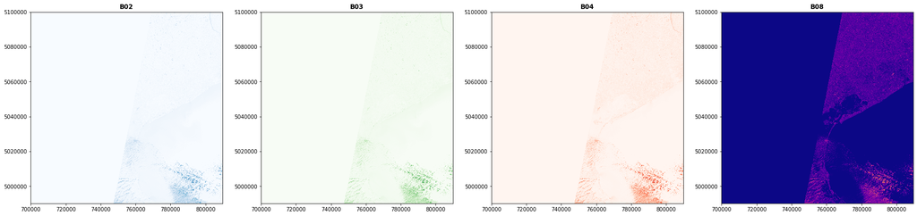

```python
fig, axs = plt.subplots(1,4, figsize=(30,30))
show(b2, ax=axs[0], title="B02", cmap="Blues")
show(b3, ax=axs[1], title="B03", cmap="Greens")
show(b4, ax=axs[2], title="B04", cmap="Reds")
show(b8, ax=axs[3], title="B08", cmap="plasma")
plt.show()
plt.close()
```

## Creazione immagine `.tiff` RGB

```python
with rio.open('./imgs/RGB.tiff','w',driver='Gtiff', width=b4.width, height=b4.height, count=3,crs=b4.crs,transform=b4.transform, dtype=b4.dtypes[0]) as rgb:
    rgb.write(b2.read(1),3) # Red
    rgb.write(b3.read(1),2) # Green
    rgb.write(b4.read(1),1) # Blue
```

## Clip dell'immagine all'area di studio

- Le immagini native sono troppo grandi, vanno clippate alla shape selezionata

```python
# Dobbiamo proiettare le coordinate sul crs dell'immagine scaricata
footprint = gpd.read_file(GEOJSON_FILE)
footprint_proj = footprint.to_crs({'init': b4.crs})

# Clip dell'immagine
with rio.open("./imgs/RGB.tiff") as src:
    out_image, out_transform = rio.mask.mask(src, footprint_proj.geometry ,crop=True)
    out_meta = src.meta.copy()
    out_meta.update({"driver": "GTiff",
                 "height": out_image.shape[1],
                 "width": out_image.shape[2],
                 "transform": out_transform})

with rio.open("./imgs/RGB_masked.tif", "w", **out_meta) as dest:
    dest.write(out_image)
```

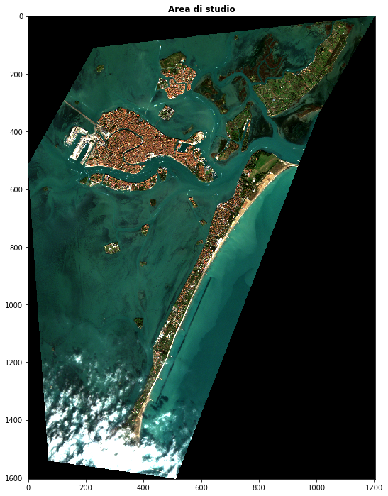

```python
#@title Contrasto { run: "auto", vertical-output: true }
CONTRAST = 4 #@param {type:"slider", min:1, max:10, step:1}

with rio.open(r"./imgs/RGB_masked.tif") as msk:

    # Correzione dati RGB
    img = msk.read([1,2,3]).astype(np.float)
    img[0] /= img[0].max()
    img[1] /= img[1].max()
    img[2] /= img[2].max()

    fig, ax = plt.subplots(1, figsize=(12, 12))
    show(np.clip((img*CONTRAST),0,1), title="Area di studio")

# Correzione canali
img_new = np.clip((img*CONTRAST*255),0,255).astype(np.uint8)
img_new = np.transpose(img_new, (1,2,0))

# Scrittura immagine
imageio.imsave("./imgs/risultato.jpg", img_new)
```

## Sharpening Immagine

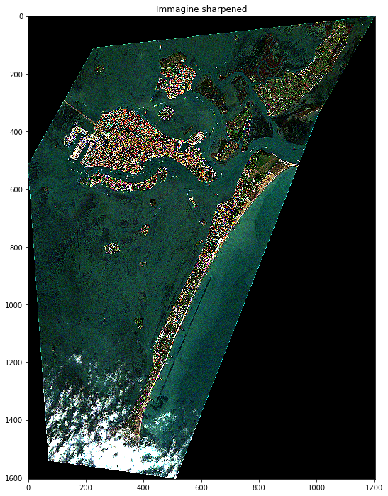

```python
kernel_sharpening = np.array([[-1,-1,-1],
                              [-1, 9,-1],
                              [-1,-1,-1]])
sharpened = cv2.filter2D(img_new, -1, kernel_sharpening)
fig, ax = plt.subplots(1, figsize=(12, 12))
ax.imshow(sharpened)
plt.title("Immagine sharpened")
imageio.imsave("./imgs/risultato_sharpened.jpg", sharpened)
```

# Calcolo Indici

## NDVI

Normalized Difference Vegetation Index

$ndvi = \frac{nir-red}{nir+red}$

```python
nir = b8.read(1).astype(float)
green = b3.read(1).astype(float)
red = b4.read(1).astype(float)

ndvi = (nir-red)/(nir+red+1e-16)
```

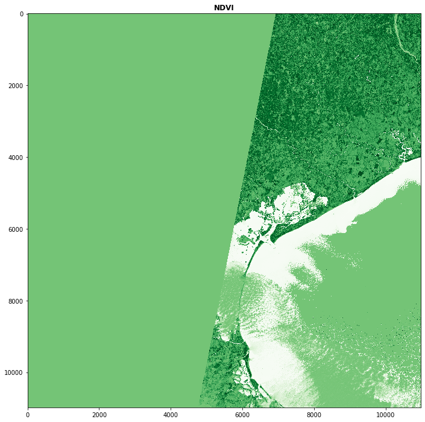

```python
plt.figure(figsize=(12,12))
show(ndvi+1, title="NDVI", cmap="Greens")
plt.close()
```

### Creazione Video soglie

```python
for i in range(10):
    fig = plt.figure(frameon=False)
    ax = plt.Axes(fig, [0., 0., 1., 1.])
    ax.set_axis_off()
    fig.add_axes(ax)
    ax.imshow(ndvi>(i/10), cmap="Greens")
    fig.savefig(f"./video/{i:03}.jpg", dpi=150)
    plt.close()

!ffmpeg -y -loglevel panic -framerate 1 -i "./video/00%d.jpg" ./video/query_video.mp4
playvideo("./video/query_video.mp4")
```

[video not shown]

### Clip NDVI al footprint

```python
with rio.open('./imgs/ndvi.tiff','w',driver='Gtiff', width=b4.width, height=b4.height, count=1,crs=b4.crs,transform=b4.transform, dtype='float64') as ndvi_tiff:
    ndvi_tiff.write(ndvi,1)
```

[output not shown]

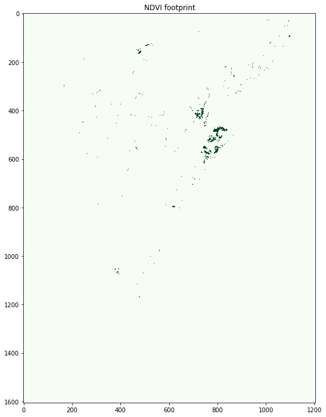

```python
#@title NDVI Footprint { run: "auto", vertical-output: true }

SOGLIA = 0.9 #@param {type:"slider", min:0, max:1, step:0.1}

with rio.open("./imgs/ndvi.tiff") as src:
    out_image, out_transform = rio.mask.mask(src, footprint_proj.geometry ,crop=True)
    out_image = out_image[0,:,:]
    out_image /= out_image.max()
    out_image = np.clip(out_image,0,1)
    plt.figure( figsize=(12,12))
    plt.imshow(out_image>SOGLIA, cmap='Greens')
    plt.title("NDVI footprint")
    #plt.savefig("./imgs/ndvi_masked.jpg", dpi=300)
    imageio.imwrite("./imgs/ndvi_masked.jpg", out_image)
```

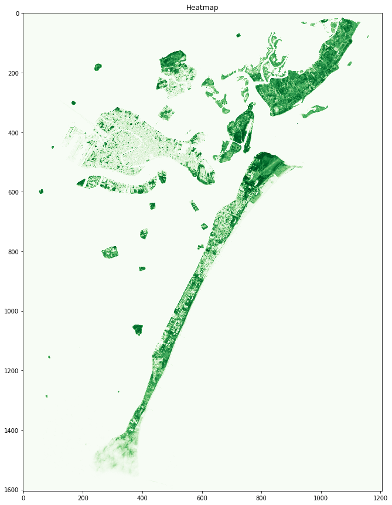

```python
# Plot heatmap NDVI

plt.figure(figsize=(15,15))
plt.imshow(out_image, cmap='Greens')
plt.title("Heatmap")
```

# Hands on LAB 👩‍💻

## CVI

Ora tocca a voi...calcoliamo il Clorophyll Vegetation Index :)

1. Implementare il calcolo dell'indice usando le bande
2. Visualizzare l'heatmap dell'indice CVI

**Calcolo Index:**

$cvi = nir \cdot \frac{red}{green^{2}}$

**Hints:**

- Se non visualizzi il CVI put your Data Scientist hat :)

```python
#-------------------------------Calcolo CVI-------------------------------------

cvi =

#-------------------------------------------------------------------------------

with rio.open('./imgs/cvi.tiff','w',driver='Gtiff', width=b4.width, height=b4.height, count=1,crs=b4.crs,transform=b4.transform, dtype='float64') as cvi_tiff:
    cvi_tiff.write(cvi,1)
```

```python
#@title CVI Footprint { run: "auto", vertical-output: true }

SOGLIA = 2.5 #@param {type:"slider", min:0, max:10, step:0.5}


with rio.open("./imgs/cvi.tiff") as src:
  out_image, out_transform = rio.mask.mask(src, footprint_proj.geometry ,crop=True)
  out_image = out_image[0,:,:]

  plt.figure(figsize=(12,12))
  plt.imshow(out_image>SOGLIA, cmap="Greens")
  plt.title("CVI Footprint")
```

```python
#-------------Riusciamo a visualizzare lheatmap delll'indice?-------------------



#-------------------------------------------------------------------------------
```

```python
# Rilascio Risorse
# Attenzione se esegue questa cella, non è più possibile usare le bande
b2.close()
b3.close()
b4.close()
b8.close()
```

Now it's up to you :)

Thanks :)

# Risorse

- Pangeo Project a Big Data Geoscience Community - https://pangeo.io/
- Database per ricerca di indici calcolabili dai satelliti https://www.indexdatabase.de/db/is.php
- Documentazione [rasterio](https://rasterio.readthedocs.io/en/stable/) → manipolazioni immagini satellitari
- Documentazione [geopandas](http://geopandas.org/) → manipolazioni di dati geospaziali
- Documentazione [folium](https://python-visualization.github.io/folium/) → mappe interattive
- Documentazinoe [sentinelsat](https://sentinelsat.readthedocs.io/en/stable/api.html) → API per accedere ai dati dei sensori Sentinel